# GLMM Analysis Report

## Methods

Model was fitted using **lme4::lmer**.

Family: **gaussian**

Formula: **lmer(Reaction ~ Days + (Days | Subject), data = df)**

Sample size used in this fit: **18 subjects**, **180 observations**.

## Model Fitting Diagnostics

This section reports diagnostics captured automatically at fit time and should be reviewed before interpreting the results below. A singular fit, a non-convergence message, or fitting warnings do not necessarily invalidate a model, but they do mean its estimates (particularly variance components) should be interpreted with caution.

| Check | Result |
| --- | --- |
| Singular fit | NO |
| Convergence | OK |

### Warnings raised during model fitting

*No warnings were raised while fitting this model.*

## Results

### Model Summary

Full summary output of the fitted model, as printed by R.

```
## Linear mixed model fit by REML. t-tests use Satterthwaite's method ['lmerModLmerTest']
## Formula: Reaction ~ Days + (Days | Subject)
##    Data: df
##
## REML criterion at convergence: 1743.6
##
## Scaled residuals:
##     Min      1Q  Median      3Q     Max
## -3.9536 -0.4634  0.0231  0.4634  5.1793
##
## Random effects:
##  Groups   Name        Variance Std.Dev. Corr
##  Subject  (Intercept) 612.10   24.741
##           Days         35.07    5.922   0.07
##  Residual             654.94   25.592
## Number of obs: 180, groups:  Subject, 18
##
## Fixed effects:
##             Estimate Std. Error      df t value Pr(>|t|)
## (Intercept)  251.405      6.825  17.000  36.838  < 2e-16 ***
## Days          10.467      1.546  17.000   6.771 3.26e-06 ***
## ---
## Signif. codes:  0 '***' 0.001 '**' 0.01 '*' 0.05 '.' 0.1 ' ' 1
##
## Correlation of Fixed Effects:
##      (Intr)
## Days -0.138
```

### Random Effects

Both the **variance** (σ²) and the **standard deviation** (σ) of each random-effect term are shown. The residual row is the within-group (observation-level) variance.

Random-effects variance components

| Group | Effect | Variance | Std.Dev. |
| --- | --- | --- | --- |
| Subject | (Intercept) | 612.10 | 24.740 |
| Subject | Days | 35.07 | 5.922 |
| Residual | (Residual) | 654.90 | 25.590 |

Random-effects covariances and correlations

| Group | Effects | Covariance | Correlation |
| --- | --- | --- | --- |
| Subject | (Intercept) ~ Days | 9.604 | 0.06555 |

### Fixed Effects

Fixed Effects

|  | Estimate | Std. Error | df | t value | Pr(>\|t\|) |  |
| --- | --- | --- | --- | --- | --- | --- |
| (Intercept) | 251.405 | 6.825 | 17 | 36.838 | <1e-04 | *** |
| Days | 10.467 | 1.546 | 17 | 6.771 | <1e-04 | *** |

### ANOVA (Type III)

```
## Type III Analysis of Variance Table with Satterthwaite's method
##      Sum Sq Mean Sq NumDF DenDF F value    Pr(>F)
## Days  30031   30031     1    17  45.853 3.264e-06 ***
## ---
## Signif. codes:  0 '***' 0.001 '**' 0.01 '*' 0.05 '.' 0.1 ' ' 1
```

### Model Performance

Variance explained and clustering (R2, ICC)

| Metric | Value |
| --- | --- |
| R2 marginal (fixed effects only) | 0.2787 |
| R2 conditional (fixed + random effects) | 0.7992 |
| ICC (adjusted) | 0.7217 |
| ICC (unadjusted) | 0.5206 |

Information criteria and error measures

| Metric | Value |
| --- | --- |
| AIC | 1756.00 |
| AICc | 1756.00 |
| BIC | 1775.00 |
| RMSE | 23.44 |
| Sigma | 25.59 |

**How to read these measures**

- **R2 marginal**: proportion of variance explained by the fixed effects alone.
- **R2 conditional**: proportion of variance explained by the fixed and random effects together.
- **ICC**: proportion of the total (non-fixed-effect) variance attributable to differences between groups/subjects; higher values mean observations within the same group are more alike.
- This model was fitted by REML: AIC/BIC are only comparable between models with identical fixed effects. Refit by ML to compare models with different fixed effects.

### DHARMa Residual Diagnostics

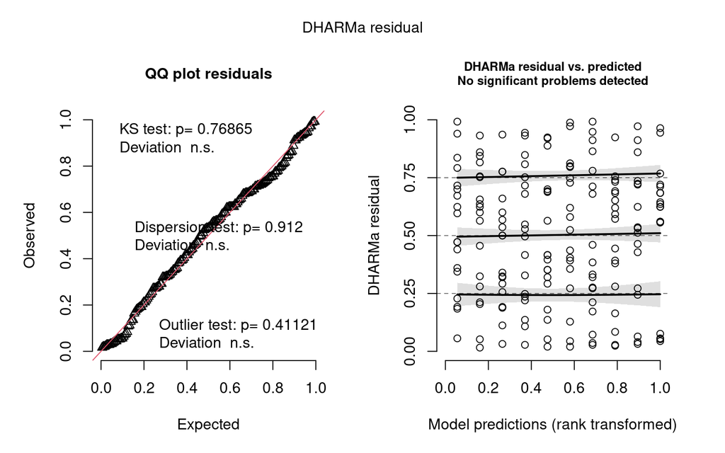